# Introduction to tidymodels

Author

Mick Cooney mickcooney@gmail.com

# 1 Workshop 1 - Build a Model

## 1.1 Retrieve and Load the Data

```r
# Data were assembled for a tutorial
# at https://www.flutterbys.com.au/stats/tut/tut7.5a.html
urchins_tbl <- read_csv(
    "https://tidymodels.org/start/models/urchins.csv"
    ) %>%
  # Change the names to be a little more verbose
  setNames(
    c("food_regime", "initial_volume", "width")
    ) %>%
  # Factors are very helpful for modeling, so we convert one column
  mutate(
    food_regime = factor(food_regime, levels = c("Initial", "Low", "High"))
    )
```

## 1.2 Plot the Data

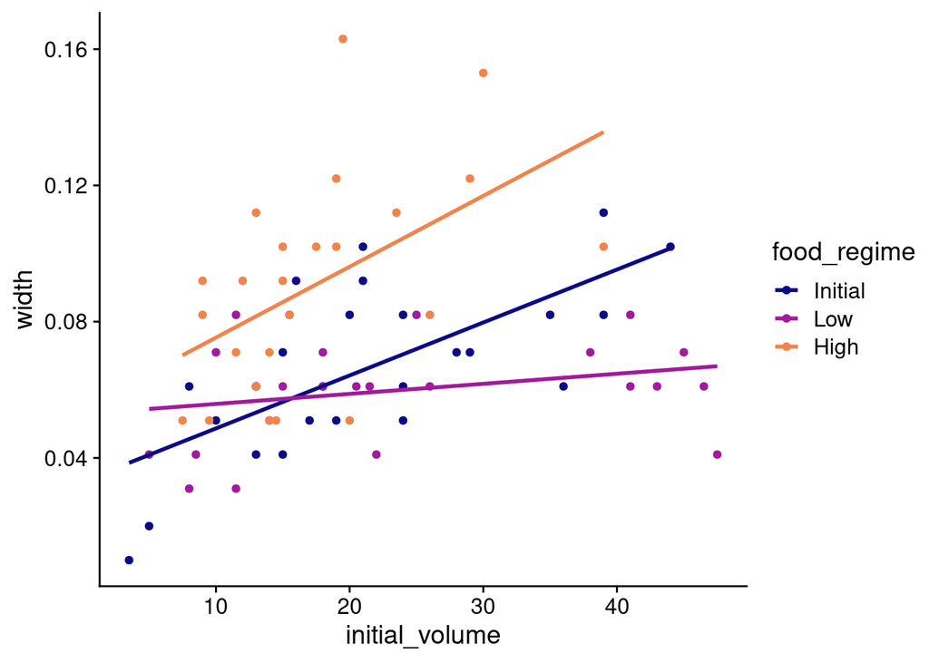

```r
ggplot(urchins_tbl,
    aes(x = initial_volume, y = width, group = food_regime, col = food_regime)
    ) +
  geom_point() +
  geom_smooth(method = lm, se = FALSE) +
  scale_color_viridis_d(option = "plasma", end = .7)
```

## 1.3 Fit First Model

```r
lm_fit <- linear_reg() %>%
  fit(
    width ~ initial_volume * food_regime,
    data = urchins_tbl
    )

lm_fit %>% print()
```

```
parsnip model object


Call:
stats::lm(formula = width ~ initial_volume * food_regime, data = data)

Coefficients:
                   (Intercept)                  initial_volume
                     0.0331216                       0.0015546
                food_regimeLow                 food_regimeHigh
                     0.0197824                       0.0214111
 initial_volume:food_regimeLow  initial_volume:food_regimeHigh
                    -0.0012594                       0.0005254
```

```r
lm_fit %>% tidy()
```

```
# A tibble: 6 × 5
  term                            estimate std.error statistic  p.value
  <chr>                              <dbl>     <dbl>     <dbl>    <dbl>
1 (Intercept)                     0.0331    0.00962      3.44  0.00100
2 initial_volume                  0.00155   0.000398     3.91  0.000222
3 food_regimeLow                  0.0198    0.0130       1.52  0.133
4 food_regimeHigh                 0.0214    0.0145       1.47  0.145
5 initial_volume:food_regimeLow  -0.00126   0.000510    -2.47  0.0162
6 initial_volume:food_regimeHigh  0.000525  0.000702     0.748 0.457
```

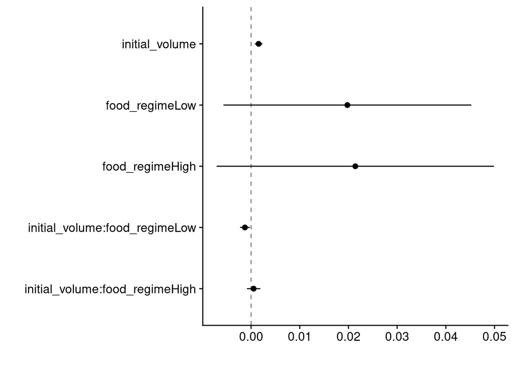

```r
lm_fit %>%
  tidy() %>%
  dwplot(
    dot_args = list(size = 2, color = "black"),
    whisker_args = list(color = "black"),
    vline = geom_vline(xintercept = 0, colour = "grey50", linetype = 2)
    )
```

## 1.4 Predit From First Model

```r
new_points_tbl <- expand.grid(
    initial_volume = 20,
    food_regime = c("Initial", "Low", "High")
    )

new_points_tbl
```

```
  initial_volume food_regime
1             20     Initial
2             20         Low
3             20        High
```

```r
mean_pred_tbl <- predict(
  lm_fit,
  new_data = new_points_tbl
  )

mean_pred_tbl %>% print()
```

```
# A tibble: 3 × 1
   .pred
   <dbl>
1 0.0642
2 0.0588
3 0.0961
```

```r
conf_int_pred_tbl <- predict(
  lm_fit,
  new_data = new_points_tbl,
  type = "conf_int"
  )

conf_int_pred_tbl %>% print()
```

```
# A tibble: 3 × 2
  .pred_lower .pred_upper
        <dbl>       <dbl>
1      0.0555      0.0729
2      0.0499      0.0678
3      0.0870      0.105
```

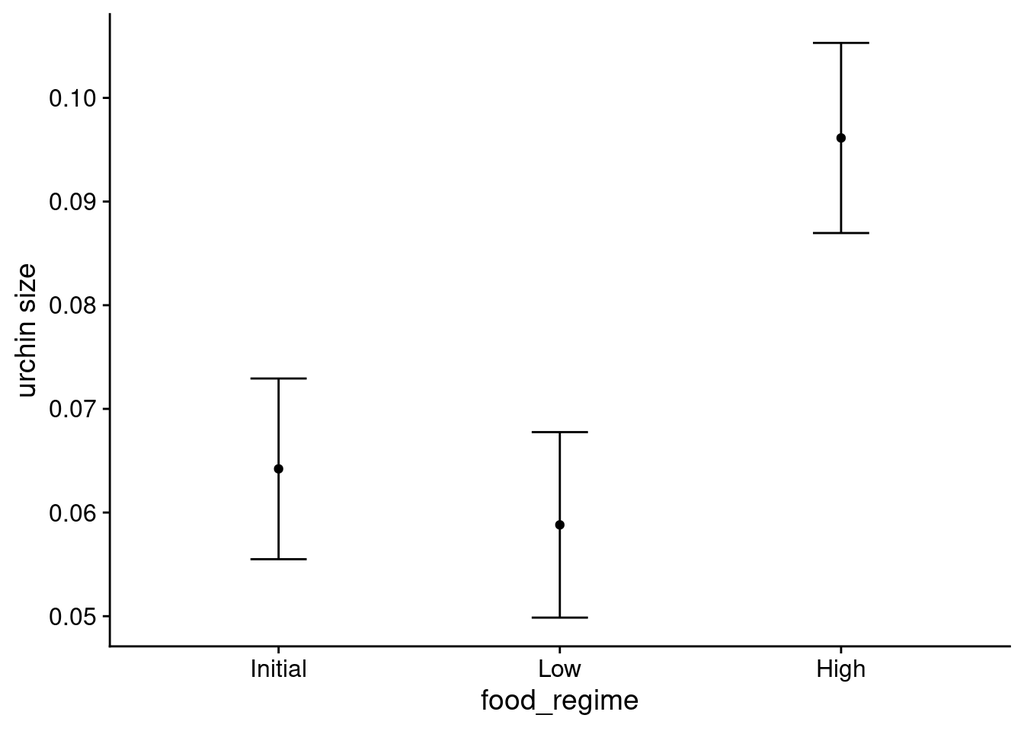

```r
plot_data_tbl <- new_points_tbl %>%
  bind_cols(mean_pred_tbl) %>%
  bind_cols(conf_int_pred_tbl)

# and plot:
ggplot(plot_data_tbl, aes(x = food_regime)) +
  geom_point(aes(y = .pred)) +
  geom_errorbar(
    aes(ymin = .pred_lower, ymax = .pred_upper),
    width = .2) +
  labs(y = "urchin size")
```

## 1.5 Fit with Stan Engine

```r
# set the prior distribution
prior_dist <- rstanarm::student_t(df = 1)

set.seed(123)

# make the parsnip model
bayes_mod <- linear_reg() %>%
  set_engine(
    "stan",
    prior_intercept = prior_dist,
    prior = prior_dist
    )

# train the model
bayes_fit <- bayes_mod %>%
  fit(
    width ~ initial_volume * food_regime,
    data = urchins_tbl
    )

print(bayes_fit, digits = 5)
```

```
parsnip model object

stan_glm
 family:       gaussian [identity]
 formula:      width ~ initial_volume * food_regime
 observations: 72
 predictors:   6
------
                               Median   MAD_SD
(Intercept)                     0.03314  0.00998
initial_volume                  0.00155  0.00040
food_regimeLow                  0.01991  0.01332
food_regimeHigh                 0.02132  0.01487
initial_volume:food_regimeLow  -0.00125  0.00051
initial_volume:food_regimeHigh  0.00053  0.00072

Auxiliary parameter(s):
      Median  MAD_SD
sigma 0.02135 0.00185

------
* For help interpreting the printed output see ?print.stanreg
* For info on the priors used see ?prior_summary.stanreg
```

```r
tidy(bayes_fit, conf.int = TRUE)
```

```
# A tibble: 6 × 5
  term                            estimate std.error  conf.low conf.high
  <chr>                              <dbl>     <dbl>     <dbl>     <dbl>
1 (Intercept)                     0.0331    0.00998   0.0167    0.0493
2 initial_volume                  0.00155   0.000402  0.000891  0.00223
3 food_regimeLow                  0.0199    0.0133   -0.00251   0.0418
4 food_regimeHigh                 0.0213    0.0149   -0.00379   0.0462
5 initial_volume:food_regimeLow  -0.00125   0.000515 -0.00212  -0.000396
6 initial_volume:food_regimeHigh  0.000533  0.000725 -0.000628  0.00170
```

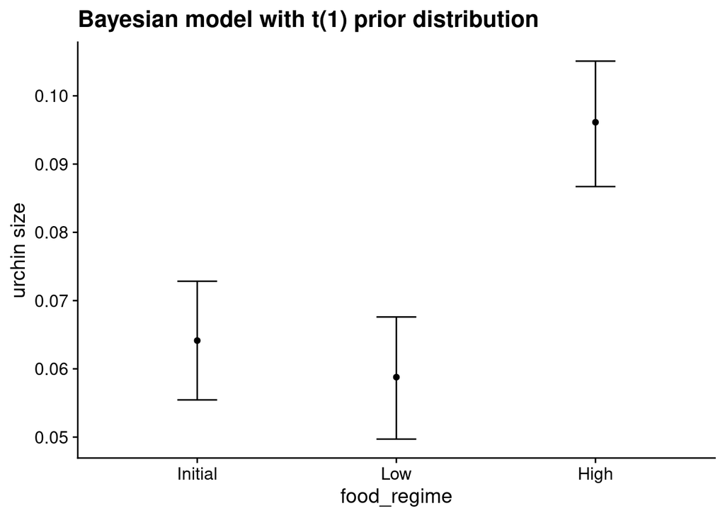

```r
bayes_plot_data <- new_points_tbl %>%
  bind_cols(predict(bayes_fit, new_data = new_points_tbl)) %>%
  bind_cols(predict(bayes_fit, new_data = new_points_tbl, type = "conf_int"))

ggplot(bayes_plot_data, aes(x = food_regime)) +
  geom_point(aes(y = .pred)) +
  geom_errorbar(aes(ymin = .pred_lower, ymax = .pred_upper), width = .2) +
  labs(y = "urchin size") +
  ggtitle("Bayesian model with t(1) prior distribution")
```

## 1.6 Extra Code

```r
urchins_tbl %>%
  group_by(food_regime) %>%
  summarize(
    med_vol = median(initial_volume)
    )
```

```
# A tibble: 3 × 2
  food_regime med_vol
  <fct>         <dbl>
1 Initial        20.5
2 Low            19.2
3 High           15
```

```r
bayes_mod %>%
  fit(
    width ~ initial_volume * food_regime,
    data = urchins_tbl
    )
```

```
parsnip model object

stan_glm
 family:       gaussian [identity]
 formula:      width ~ initial_volume * food_regime
 observations: 72
 predictors:   6
------
                               Median MAD_SD
(Intercept)                    0.0    0.0
initial_volume                 0.0    0.0
food_regimeLow                 0.0    0.0
food_regimeHigh                0.0    0.0
initial_volume:food_regimeLow  0.0    0.0
initial_volume:food_regimeHigh 0.0    0.0

Auxiliary parameter(s):
      Median MAD_SD
sigma 0.0    0.0

------
* For help interpreting the printed output see ?print.stanreg
* For info on the priors used see ?prior_summary.stanreg
```

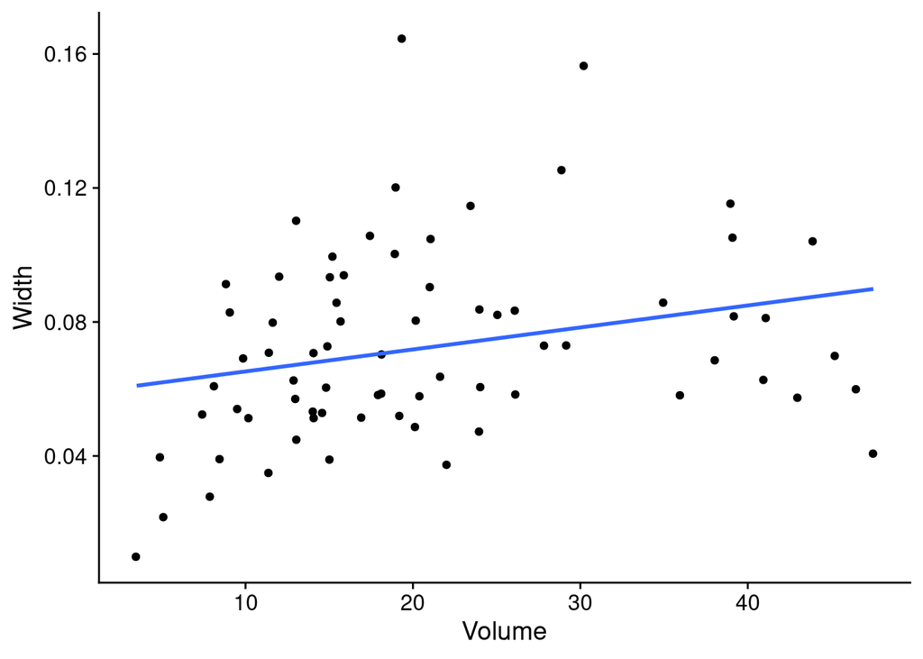

```r
ggplot(urchins_tbl,
    aes(initial_volume, width)) +      # returns a ggplot object
  geom_jitter() +                         # same
  geom_smooth(method = lm, se = FALSE) +  # same
  labs(x = "Volume", y = "Width")         # etc
```

# 2 Workshop 2 - Preprocess Data

```r
set.seed(123)

flight_data_tbl <- flights %>%
  mutate(
    # Convert the arrival delay to a factor
    arr_delay = ifelse(arr_delay >= 30, "late", "on_time"),
    arr_delay = factor(arr_delay),

    # We will use the date (not date-time) in the recipe below
    date = lubridate::as_date(time_hour)
    ) %>%

  # Include the weather data
  inner_join(weather, by = c("origin", "time_hour")) %>%

  # Only retain the specific columns we will use
  select(
    dep_time, flight, origin, dest, air_time, distance, carrier, date,
    arr_delay, time_hour
    ) %>%

  # Exclude missing data
  na.omit() %>%

  # For creating models, it is better to have qualitative columns
  # encoded as factors (instead of character strings)
  mutate_if(is.character, as.factor)

flight_data_tbl %>% glimpse()
```

```
Rows: 325,819
Columns: 10
$ dep_time  <int> 517, 533, 542, 544, 554, 554, 555, 557, 557, 558, 558, 558, …
$ flight    <int> 1545, 1714, 1141, 725, 461, 1696, 507, 5708, 79, 301, 49, 71…
$ origin    <fct> EWR, LGA, JFK, JFK, LGA, EWR, EWR, LGA, JFK, LGA, JFK, JFK, …
$ dest      <fct> IAH, IAH, MIA, BQN, ATL, ORD, FLL, IAD, MCO, ORD, PBI, TPA, …
$ air_time  <dbl> 227, 227, 160, 183, 116, 150, 158, 53, 140, 138, 149, 158, 3…
$ distance  <dbl> 1400, 1416, 1089, 1576, 762, 719, 1065, 229, 944, 733, 1028,…
$ carrier   <fct> UA, UA, AA, B6, DL, UA, B6, EV, B6, AA, B6, B6, UA, UA, AA, …
$ date      <date> 2013-01-01, 2013-01-01, 2013-01-01, 2013-01-01, 2013-01-01,…
$ arr_delay <fct> on_time, on_time, late, on_time, on_time, on_time, on_time, …
$ time_hour <dttm> 2013-01-01 05:00:00, 2013-01-01 05:00:00, 2013-01-01 05:00:…
```

```r
flight_data_tbl %>%
  count(arr_delay) %>%
  mutate(
    prop = n / sum(n)
    )
```

```
# A tibble: 2 × 3
  arr_delay      n  prop
  <fct>      <int> <dbl>
1 late       52540 0.161
2 on_time   273279 0.839
```

```r
flight_data_tbl %>%
  skimr::skim(dest, carrier)
```

Data summary

| Name | Piped data |
| --- | --- |
| Number of rows | 325819 |
| Number of columns | 10 |
| _______________________ |  |
| Column type frequency: |  |
| factor | 2 |
| ________________________ |  |
| Group variables | None |

**Variable type: factor**

| skim_variable | n_missing | complete_rate | ordered | n_unique | top_counts |
| --- | --- | --- | --- | --- | --- |
| dest | 0 | 1 | FALSE | 104 | ATL: 16771, ORD: 16507, LAX: 15942, BOS: 14948 |
| carrier | 0 | 1 | FALSE | 16 | UA: 57489, B6: 53715, EV: 50868, DL: 47465 |

## 2.1 Create Test / Train Split

```r
# Fix the random numbers by setting the seed
# This enables the analysis to be reproducible when random numbers are used
set.seed(222)

# Put 3/4 of the data into the training set
data_split <- initial_split(flight_data_tbl, prop = 0.75)

# Create data frames for the two sets:
train_data_tbl <- training(data_split)
test_data_tbl  <- testing(data_split)
```

## 2.2 Create Recipes and Roles

```r
flights_recipe <- recipe(
    arr_delay ~ .,
    data = train_data_tbl
    ) %>%
  update_role(flight, time_hour, new_role = "ID")


summary(flights_recipe)
```

```
# A tibble: 10 × 4
   variable  type    role      source
   <chr>     <chr>   <chr>     <chr>
 1 dep_time  numeric predictor original
 2 flight    numeric ID        original
 3 origin    nominal predictor original
 4 dest      nominal predictor original
 5 air_time  numeric predictor original
 6 distance  numeric predictor original
 7 carrier   nominal predictor original
 8 date      date    predictor original
 9 time_hour date    ID        original
10 arr_delay nominal outcome   original
```

We now want to add some additional fields

```r
flights_recipe <- recipe(
    arr_delay ~ .,
    data = train_data_tbl
    ) %>%
  update_role(flight, time_hour, new_role = "ID") %>%
  step_date(date, features = c("dow", "month")) %>%
  step_holiday(
    date,
    holidays = timeDate::listHolidays("US"),
    keep_original_cols = FALSE
    ) %>%
  step_dummy(all_nominal_predictors()) %>%
  step_zv(all_predictors())
```

## 2.3 Fit Model with Recipe

```r
lr_mod <- logistic_reg() %>%
  set_engine("glm")

flights_wflow <- workflow() %>%
  add_model(lr_mod) %>%
  add_recipe(flights_recipe)

flights_wflow %>% print()
```

```
══ Workflow ════════════════════════════════════════════════════════════════════
Preprocessor: Recipe
Model: logistic_reg()

── Preprocessor ────────────────────────────────────────────────────────────────
4 Recipe Steps

• step_date()
• step_holiday()
• step_dummy()
• step_zv()

── Model ───────────────────────────────────────────────────────────────────────
Logistic Regression Model Specification (classification)

Computational engine: glm
```

```r
flights_fit <- flights_wflow %>%
  fit(data = train_data_tbl)

flights_fit %>% print()
```

```
══ Workflow [trained] ══════════════════════════════════════════════════════════
Preprocessor: Recipe
Model: logistic_reg()

── Preprocessor ────────────────────────────────────────────────────────────────
4 Recipe Steps

• step_date()
• step_holiday()
• step_dummy()
• step_zv()

── Model ───────────────────────────────────────────────────────────────────────

Call:  stats::glm(formula = ..y ~ ., family = stats::binomial, data = data)

Coefficients:
                 (Intercept)                      dep_time
                    7.276446                     -0.001664
                    air_time                      distance
                   -0.044014                      0.005071
         date_USChristmasDay            date_USColumbusDay
                    1.329336                      0.723927
    date_USCPulaskisBirthday  date_USDecorationMemorialDay
                    0.807165                      0.584694
          date_USElectionDay             date_USGoodFriday
                    0.947652                      1.246811
      date_USInaugurationDay        date_USIndependenceDay
                    0.228947                      2.119747
             date_USLaborDay       date_USLincolnsBirthday
                   -1.933737                      0.583750
          date_USMemorialDay        date_USMLKingsBirthday
                    1.519217                      0.428585
          date_USNewYearsDay          date_USPresidentsDay
                    0.204203                      0.483797
      date_USThanksgivingDay            date_USVeteransDay
                    0.152978                      0.717895
  date_USWashingtonsBirthday                    origin_JFK
                    0.043305                      0.107289
                  origin_LGA                      dest_ACK
```

[output cut: 11 more lines]

```
                    dest_BQN                      dest_BTV
                   -1.524842                     -1.573955
                    dest_BUF                      dest_BUR
                   -1.474470                      0.128706
                    dest_BWI                      dest_BZN
                   -1.678767                     -2.082842
                    dest_CAE                      dest_CAK
                   -2.001807                     -1.620195
                    dest_CHO                      dest_CHS
                   -0.634494                     -1.480732
                    dest_CLE                      dest_CLT
                   -1.387610                     -1.586758

...
and 116 more lines.
```

```r
flights_fit %>%
  extract_fit_parsnip() %>%
  tidy()
```

```
# A tibble: 157 × 5
   term                         estimate std.error statistic  p.value
   <chr>                           <dbl>     <dbl>     <dbl>    <dbl>
 1 (Intercept)                   7.28    2.73           2.67 7.64e- 3
 2 dep_time                     -0.00166 0.0000141   -118.   0
 3 air_time                     -0.0440  0.000563     -78.2  0
 4 distance                      0.00507 0.00150        3.38 7.32e- 4
 5 date_USChristmasDay           1.33    0.177          7.49 6.93e-14
 6 date_USColumbusDay            0.724   0.170          4.25 2.13e- 5
 7 date_USCPulaskisBirthday      0.807   0.139          5.80 6.57e- 9
 8 date_USDecorationMemorialDay  0.585   0.117          4.98 6.32e- 7
 9 date_USElectionDay            0.948   0.190          4.98 6.25e- 7
10 date_USGoodFriday             1.25    0.167          7.45 9.40e-14
# … with 147 more rows
```

## 2.4 Predict with Workflow

```r
flights_fit %>% predict(test_data_tbl)
```

```
# A tibble: 81,455 × 1
   .pred_class
   <fct>
 1 on_time
 2 on_time
 3 on_time
 4 on_time
 5 on_time
 6 on_time
 7 on_time
 8 on_time
 9 on_time
10 on_time
# … with 81,445 more rows
```

```r
flights_aug_tbl <- augment(flights_fit, test_data_tbl)

# The data look like:
flights_aug_tbl %>%
  select(arr_delay, time_hour, flight, .pred_class, .pred_on_time)
```

```
# A tibble: 81,455 × 5
   arr_delay time_hour           flight .pred_class .pred_on_time
   <fct>     <dttm>               <int> <fct>               <dbl>
 1 on_time   2013-01-01 05:00:00   1545 on_time             0.945
 2 on_time   2013-01-01 05:00:00   1714 on_time             0.949
 3 on_time   2013-01-01 06:00:00    507 on_time             0.964
 4 on_time   2013-01-01 06:00:00   5708 on_time             0.961
 5 on_time   2013-01-01 06:00:00     71 on_time             0.962
 6 on_time   2013-01-01 06:00:00    194 on_time             0.975
 7 on_time   2013-01-01 06:00:00   1124 on_time             0.963
 8 on_time   2013-01-01 05:00:00   1806 on_time             0.981
 9 on_time   2013-01-01 06:00:00   1187 on_time             0.935
10 on_time   2013-01-01 06:00:00   4650 on_time             0.931
# … with 81,445 more rows
```

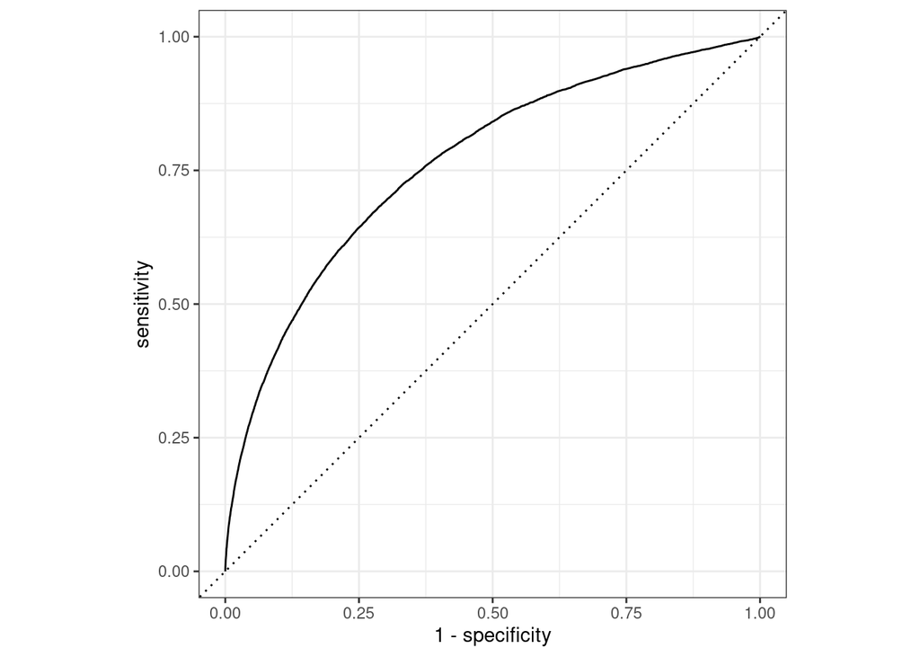

```r
flights_aug_tbl %>%
  roc_curve(truth = arr_delay, .pred_late) %>%
  autoplot()
```

```r
flights_aug_tbl %>%
  roc_auc(truth = arr_delay, .pred_late)
```

```
# A tibble: 1 × 3
  .metric .estimator .estimate
  <chr>   <chr>          <dbl>
1 roc_auc binary         0.764
```

Check how useful the recipe has been.

```r
workflow() %>%
  add_model(lr_mod) %>%
  add_formula(arr_delay ~ .) %>%
  fit(data = train_data_tbl %>% select(-flight, -time_hour)) %>%
  augment(test_data_tbl) %>%
  roc_auc(truth = arr_delay, .pred_late)
```

```
# A tibble: 1 × 3
  .metric .estimator .estimate
  <chr>   <chr>          <dbl>
1 roc_auc binary         0.735
```

# 3 Workshop 3 - Evaluate Models with Resampling

## 3.1 Load Data and Create Stratified Split

```r
data(cells, package = "modeldata")

cells_tbl <- cells %>% as_tibble()

cells_tbl %>% glimpse()
```

```
Rows: 2,019
Columns: 58
$ case                         <fct> Test, Train, Train, Train, Test, Test, Te…
$ class                        <fct> PS, PS, WS, PS, PS, WS, WS, PS, WS, WS, W…
$ angle_ch_1                   <dbl> 143.247705, 133.752037, 106.646387, 69.15…
$ area_ch_1                    <int> 185, 819, 431, 298, 285, 172, 177, 251, 4…
$ avg_inten_ch_1               <dbl> 15.71186, 31.92327, 28.03883, 19.45614, 2…
$ avg_inten_ch_2               <dbl> 4.954802, 206.878517, 116.315534, 102.294…
$ avg_inten_ch_3               <dbl> 9.548023, 69.916880, 63.941748, 28.217544…
$ avg_inten_ch_4               <dbl> 2.214689, 164.153453, 106.696602, 31.0280…
$ convex_hull_area_ratio_ch_1  <dbl> 1.124509, 1.263158, 1.053310, 1.202625, 1…
$ convex_hull_perim_ratio_ch_1 <dbl> 0.9196827, 0.7970801, 0.9354750, 0.865829…
$ diff_inten_density_ch_1      <dbl> 29.51923, 31.87500, 32.48771, 26.73228, 3…
$ diff_inten_density_ch_3      <dbl> 13.77564, 43.12228, 35.98577, 22.91732, 2…
$ diff_inten_density_ch_4      <dbl> 6.826923, 79.308424, 51.357050, 26.393701…
```

[output cut: 45 more lines]

We now want to segment the data. This data was pre-segmented via the `case` field, but we will create our own splits.

```r
set.seed(123)

cell_split <- initial_split(
  cells %>% select(-case),
  strata = class
  )


cell_train_tbl <- training(cell_split)
cell_test_tbl  <- testing(cell_split)

# training set proportions by class
cell_train_tbl %>%
  count(class) %>%
  mutate(
    prop = n / sum(n)
    )
```

```
# A tibble: 2 × 3
  class     n  prop
  <fct> <int> <dbl>
1 PS      975 0.644
2 WS      539 0.356
```

```r
# test set proportions by class
cell_test_tbl %>%
  count(class) %>%
  mutate(
    prop = n / sum(n)
    )
```

```
# A tibble: 2 × 3
  class     n  prop
  <fct> <int> <dbl>
1 PS      325 0.644
2 WS      180 0.356
```

## 3.2 Construct Random Forest Model

We initially want to fit the Random Forest model for this classification

```r
rf_mod <- rand_forest(trees = 1000) %>%
  set_engine("ranger") %>%
  set_mode("classification")


set.seed(234)

rf_fit <- rf_mod %>%
  fit(
    class ~ .,
    data = cell_train_tbl
    )

rf_fit %>% print()
```

```
parsnip model object

Ranger result

Call:
 ranger::ranger(x = maybe_data_frame(x), y = y, num.trees = ~1000,      num.threads = 1, verbose = FALSE, seed = sample.int(10^5,          1), probability = TRUE)

Type:                             Probability estimation
Number of trees:                  1000
Sample size:                      1514
Number of independent variables:  56
Mtry:                             7
Target node size:                 10
Variable importance mode:         none
Splitrule:                        gini
OOB prediction error (Brier s.):  0.1187479
```

```r
rf_training_pred_tbl <- predict(rf_fit, cell_train_tbl) %>%
  bind_cols(predict(rf_fit, cell_train_tbl, type = "prob")) %>%
  # Add the true outcome data back in
  bind_cols(cell_train_tbl %>% select(class))

rf_training_pred_tbl %>% glimpse()
```

```
Rows: 1,514
Columns: 4
$ .pred_class <fct> PS, PS, PS, PS, PS, PS, PS, PS, PS, PS, PS, PS, PS, PS, PS…
$ .pred_PS    <dbl> 0.7395460, 0.9402575, 0.9293341, 0.9593913, 0.9261619, 0.6…
$ .pred_WS    <dbl> 0.260453968, 0.059742460, 0.070665873, 0.040608730, 0.0738…
$ class       <fct> PS, PS, PS, PS, PS, PS, PS, PS, PS, PS, PS, PS, PS, PS, PS…
```

```r
rf_training_pred_tbl %>% roc_auc( truth = class, .pred_PS)
```

```
# A tibble: 1 × 3
  .metric .estimator .estimate
  <chr>   <chr>          <dbl>
1 roc_auc binary          1.00
```

```r
rf_training_pred_tbl %>% accuracy(truth = class, .pred_class)
```

```
# A tibble: 1 × 3
  .metric  .estimator .estimate
  <chr>    <chr>          <dbl>
1 accuracy binary         0.990
```

Calculate the out-of-sample test data predictions.

```r
rf_testing_pred_tbl <- predict(rf_fit, cell_test_tbl) %>%
  bind_cols(predict(rf_fit, cell_test_tbl, type = "prob")) %>%
  bind_cols(cell_test_tbl %>% select(class))

rf_testing_pred_tbl %>% glimpse()
```

```
Rows: 505
Columns: 4
$ .pred_class <fct> PS, PS, WS, PS, PS, WS, PS, WS, PS, WS, PS, PS, WS, PS, WS…
$ .pred_PS    <dbl> 0.89297302, 0.92031984, 0.08005119, 0.81651230, 0.75193452…
$ .pred_WS    <dbl> 0.107026984, 0.079680159, 0.919948810, 0.183487698, 0.2480…
$ class       <fct> PS, PS, WS, WS, PS, WS, PS, WS, PS, WS, PS, WS, WS, PS, PS…
```

```r
rf_testing_pred_tbl %>% roc_auc( truth = class, .pred_PS)
```

```
# A tibble: 1 × 3
  .metric .estimator .estimate
  <chr>   <chr>          <dbl>
1 roc_auc binary         0.891
```

```r
rf_testing_pred_tbl %>% accuracy(truth = class, .pred_class)
```

```
# A tibble: 1 × 3
  .metric  .estimator .estimate
  <chr>    <chr>          <dbl>
1 accuracy binary         0.814
```

## 3.3 Fit Model with Resampling

```r
set.seed(345)

folds <- vfold_cv(cell_train_tbl, v = 10)

folds %>% glimpse()
```

```
Rows: 10
Columns: 2
$ splits <list> [<vfold_split[1362 x 152 x 1514 x 57]>], [<vfold_split[1362 x …
$ id     <chr> "Fold01", "Fold02", "Fold03", "Fold04", "Fold05", "Fold06", "Fo…
```

```r
rf_wf <- workflow() %>%
  add_model(rf_mod) %>%
  add_formula(class ~ .)

set.seed(456)

rf_fit_rs <- rf_wf %>%
  fit_resamples(folds)

rf_fit_rs %>% print()
```

```
# Resampling results
# 10-fold cross-validation
# A tibble: 10 × 4
   splits             id     .metrics         .notes
   <list>             <chr>  <list>           <list>
 1 <split [1362/152]> Fold01 <tibble [2 × 4]> <tibble [0 × 3]>
 2 <split [1362/152]> Fold02 <tibble [2 × 4]> <tibble [0 × 3]>
 3 <split [1362/152]> Fold03 <tibble [2 × 4]> <tibble [0 × 3]>
 4 <split [1362/152]> Fold04 <tibble [2 × 4]> <tibble [0 × 3]>
 5 <split [1363/151]> Fold05 <tibble [2 × 4]> <tibble [0 × 3]>
 6 <split [1363/151]> Fold06 <tibble [2 × 4]> <tibble [0 × 3]>
 7 <split [1363/151]> Fold07 <tibble [2 × 4]> <tibble [0 × 3]>
 8 <split [1363/151]> Fold08 <tibble [2 × 4]> <tibble [0 × 3]>
 9 <split [1363/151]> Fold09 <tibble [2 × 4]> <tibble [0 × 3]>
10 <split [1363/151]> Fold10 <tibble [2 × 4]> <tibble [0 × 3]>
```

```r
collect_metrics(rf_fit_rs)
```

```
# A tibble: 2 × 6
  .metric  .estimator  mean     n std_err .config
  <chr>    <chr>      <dbl> <int>   <dbl> <chr>
1 accuracy binary     0.833    10 0.00876 Preprocessor1_Model1
2 roc_auc  binary     0.905    10 0.00627 Preprocessor1_Model1
```

```r
rf_testing_pred_tbl %>% roc_auc( truth = class, .pred_PS)
```

```
# A tibble: 1 × 3
  .metric .estimator .estimate
  <chr>   <chr>          <dbl>
1 roc_auc binary         0.891
```

```r
rf_testing_pred_tbl %>% accuracy(truth = class, .pred_class)
```

```
# A tibble: 1 × 3
  .metric  .estimator .estimate
  <chr>    <chr>          <dbl>
1 accuracy binary         0.814
```

# 4 Workshop 4 - Tune Model Parameters

```r
tune_spec <- decision_tree(
    cost_complexity = tune(),
    tree_depth = tune()
    ) %>%
  set_engine("rpart") %>%
  set_mode("classification")

tune_spec %>% print()
```

```
Decision Tree Model Specification (classification)

Main Arguments:
  cost_complexity = tune()
  tree_depth = tune()

Computational engine: rpart
```

## 4.1 Model Tuning on Grid

We now want to set up the tuning process on a grid.

```r
tree_grid_tbl <- grid_regular(
  cost_complexity(),
  tree_depth(),
  levels = 5
  )

tree_grid_tbl %>% print()
```

```
# A tibble: 25 × 2
   cost_complexity tree_depth
             <dbl>      <int>
 1    0.0000000001          1
 2    0.0000000178          1
 3    0.00000316            1
 4    0.000562              1
 5    0.1                   1
 6    0.0000000001          4
 7    0.0000000178          4
 8    0.00000316            4
 9    0.000562              4
10    0.1                   4
# … with 15 more rows
```

```r
tree_grid_tbl %>% count(tree_depth)
```

```
# A tibble: 5 × 2
  tree_depth     n
       <int> <int>
1          1     5
2          4     5
3          8     5
4         11     5
5         15     5
```

```r
set.seed(234)

cell_folds <- vfold_cv(cell_train_tbl)

cell_folds %>% glimpse()
```

```
Rows: 10
Columns: 2
$ splits <list> [<vfold_split[1362 x 152 x 1514 x 57]>], [<vfold_split[1362 x …
$ id     <chr> "Fold01", "Fold02", "Fold03", "Fold04", "Fold05", "Fold06", "Fo…
```

```r
set.seed(345)

tree_wf <- workflow() %>%
  add_model(tune_spec) %>%
  add_formula(class ~ .)

tree_res <- tree_wf %>%
  tune_grid(
    resamples = cell_folds,
    grid      = tree_grid_tbl
    )

tree_res %>% print()
```

```
# Tuning results
# 10-fold cross-validation
# A tibble: 10 × 4
   splits             id     .metrics          .notes
   <list>             <chr>  <list>            <list>
 1 <split [1362/152]> Fold01 <tibble [50 × 6]> <tibble [0 × 3]>
 2 <split [1362/152]> Fold02 <tibble [50 × 6]> <tibble [0 × 3]>
 3 <split [1362/152]> Fold03 <tibble [50 × 6]> <tibble [0 × 3]>
 4 <split [1362/152]> Fold04 <tibble [50 × 6]> <tibble [0 × 3]>
 5 <split [1363/151]> Fold05 <tibble [50 × 6]> <tibble [0 × 3]>
 6 <split [1363/151]> Fold06 <tibble [50 × 6]> <tibble [0 × 3]>
 7 <split [1363/151]> Fold07 <tibble [50 × 6]> <tibble [0 × 3]>
 8 <split [1363/151]> Fold08 <tibble [50 × 6]> <tibble [0 × 3]>
 9 <split [1363/151]> Fold09 <tibble [50 × 6]> <tibble [0 × 3]>
10 <split [1363/151]> Fold10 <tibble [50 × 6]> <tibble [0 × 3]>
```

```r
tree_res %>% collect_metrics()
```

```
# A tibble: 50 × 8
   cost_complexity tree_depth .metric  .estimator  mean     n std_err .config
             <dbl>      <int> <chr>    <chr>      <dbl> <int>   <dbl> <chr>
 1    0.0000000001          1 accuracy binary     0.732    10  0.0148 Preproces…
 2    0.0000000001          1 roc_auc  binary     0.777    10  0.0107 Preproces…
 3    0.0000000178          1 accuracy binary     0.732    10  0.0148 Preproces…
 4    0.0000000178          1 roc_auc  binary     0.777    10  0.0107 Preproces…
 5    0.00000316            1 accuracy binary     0.732    10  0.0148 Preproces…
 6    0.00000316            1 roc_auc  binary     0.777    10  0.0107 Preproces…
 7    0.000562              1 accuracy binary     0.732    10  0.0148 Preproces…
 8    0.000562              1 roc_auc  binary     0.777    10  0.0107 Preproces…
 9    0.1                   1 accuracy binary     0.732    10  0.0148 Preproces…
10    0.1                   1 roc_auc  binary     0.777    10  0.0107 Preproces…
# … with 40 more rows
```

We now want to plot the outputs of these fits.

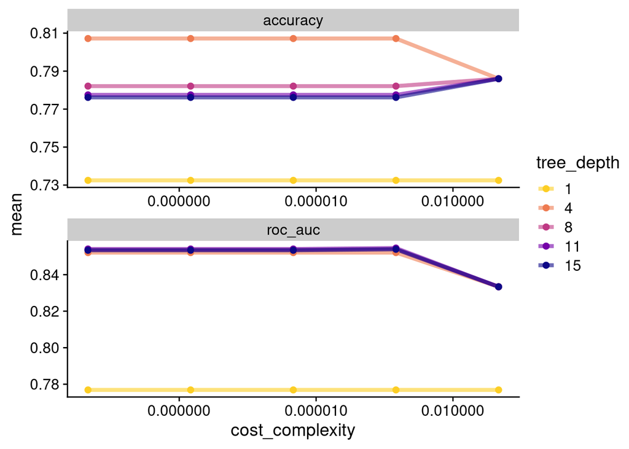

```r
tree_res_tbl <- tree_res %>%
  collect_metrics() %>%
  mutate(
    tree_depth = factor(tree_depth)
    )

ggplot(
    tree_res_tbl,
    aes(cost_complexity, mean, color = tree_depth)
    ) +
  geom_line(size = 1.5, alpha = 0.6) +
  geom_point(size = 2) +
  facet_wrap(~ .metric, scales = "free", nrow = 2) +
  scale_x_log10(labels = scales::label_number()) +
  scale_color_viridis_d(option = "plasma", begin = .9, end = 0)
```

```r
tree_res %>%
  show_best("accuracy")
```

```
# A tibble: 5 × 8
  cost_complexity tree_depth .metric  .estimator  mean     n std_err .config
            <dbl>      <int> <chr>    <chr>      <dbl> <int>   <dbl> <chr>
1    0.0000000001          4 accuracy binary     0.807    10  0.0119 Preprocess…
2    0.0000000178          4 accuracy binary     0.807    10  0.0119 Preprocess…
3    0.00000316            4 accuracy binary     0.807    10  0.0119 Preprocess…
4    0.000562              4 accuracy binary     0.807    10  0.0119 Preprocess…
5    0.1                   4 accuracy binary     0.786    10  0.0124 Preprocess…
```

```r
best_tree <- tree_res %>%
  select_best("accuracy")
```

Now that we have chosen the ‘best’ fit, we can finish off our workflow to choose that one.

```r
final_wf <- tree_wf %>%
  finalize_workflow(best_tree)

final_wf %>% print()
```

```
══ Workflow ════════════════════════════════════════════════════════════════════
Preprocessor: Formula
Model: decision_tree()

── Preprocessor ────────────────────────────────────────────────────────────────
class ~ .

── Model ───────────────────────────────────────────────────────────────────────
Decision Tree Model Specification (classification)

Main Arguments:
  cost_complexity = 1e-10
  tree_depth = 4

Computational engine: rpart
```

## 4.2 Create Final Fit

```r
final_fit <- final_wf %>%
  last_fit(cell_split)

final_fit %>%
  collect_metrics()
```

```
# A tibble: 2 × 4
  .metric  .estimator .estimate .config
  <chr>    <chr>          <dbl> <chr>
1 accuracy binary         0.802 Preprocessor1_Model1
2 roc_auc  binary         0.840 Preprocessor1_Model1
```

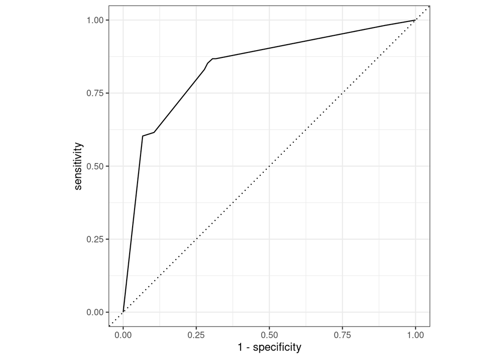

```r
final_fit %>%
  collect_predictions() %>%
  roc_curve(class, .pred_PS) %>%
  autoplot()
```

We now want to save this final version and visualise the tree where possible

```r
final_tree <- extract_workflow(final_fit)
final_tree %>% print()
```

```
══ Workflow [trained] ══════════════════════════════════════════════════════════
Preprocessor: Formula
Model: decision_tree()

── Preprocessor ────────────────────────────────────────────────────────────────
class ~ .

── Model ───────────────────────────────────────────────────────────────────────
n= 1514

node), split, n, loss, yval, (yprob)
      * denotes terminal node

 1) root 1514 539 PS (0.64398943 0.35601057)
   2) total_inten_ch_2< 41732.5 642  33 PS (0.94859813 0.05140187)
     4) shape_p_2_a_ch_1>=1.251801 631  27 PS (0.95721078 0.04278922) *
     5) shape_p_2_a_ch_1< 1.251801 11   5 WS (0.45454545 0.54545455) *
   3) total_inten_ch_2>=41732.5 872 366 WS (0.41972477 0.58027523)
     6) fiber_width_ch_1< 11.37318 406 160 PS (0.60591133 0.39408867)
      12) avg_inten_ch_1< 145.4883 293  85 PS (0.70989761 0.29010239) *
      13) avg_inten_ch_1>=145.4883 113  38 WS (0.33628319 0.66371681)
        26) total_inten_ch_3>=57919.5 33  10 PS (0.69696970 0.30303030) *
        27) total_inten_ch_3< 57919.5 80  15 WS (0.18750000 0.81250000) *
     7) fiber_width_ch_1>=11.37318 466 120 WS (0.25751073 0.74248927)
      14) eq_ellipse_oblate_vol_ch_1>=1673.942 30   8 PS (0.73333333 0.26666667)
        28) var_inten_ch_3>=41.10858 20   2 PS (0.90000000 0.10000000) *
        29) var_inten_ch_3< 41.10858 10   4 WS (0.40000000 0.60000000) *
      15) eq_ellipse_oblate_vol_ch_1< 1673.942 436  98 WS (0.22477064 0.77522936) *
```

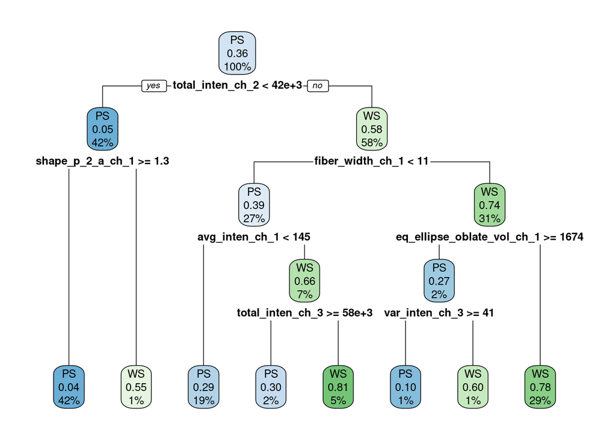

```r
final_tree %>%
  extract_fit_engine() %>%
  rpart.plot(roundint = FALSE)
```

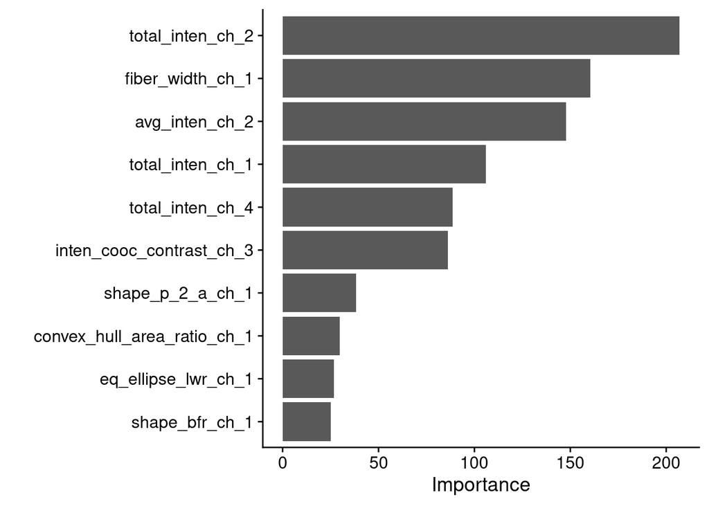

```r
final_tree %>%
  extract_fit_parsnip() %>%
  vip()
```

```r
args(decision_tree)
```

```
function (mode = "unknown", engine = "rpart", cost_complexity = NULL,
    tree_depth = NULL, min_n = NULL)
NULL
```

# 5 Workshop 5 - Case Study

## 5.1 Load Hotel Data

```r
hotels_tbl <- read_csv(
    file = 'https://tidymodels.org/start/case-study/hotels.csv'
    ) %>%
  mutate(
    across(where(is.character), as.factor)
    )
hotels_tbl %>% glimpse()
```

```
Rows: 50,000
Columns: 23
$ hotel                          <fct> City_Hotel, City_Hotel, Resort_Hotel, R…
$ lead_time                      <dbl> 217, 2, 95, 143, 136, 67, 47, 56, 80, 6…
$ stays_in_weekend_nights        <dbl> 1, 0, 2, 2, 1, 2, 0, 0, 0, 2, 1, 0, 1, …
$ stays_in_week_nights           <dbl> 3, 1, 5, 6, 4, 2, 2, 3, 4, 2, 2, 1, 2, …
$ adults                         <dbl> 2, 2, 2, 2, 2, 2, 2, 0, 2, 2, 2, 1, 2, …
$ children                       <fct> none, none, none, none, none, none, chi…
$ meal                           <fct> BB, BB, BB, HB, HB, SC, BB, BB, BB, BB,…
$ country                        <fct> DEU, PRT, GBR, ROU, PRT, GBR, ESP, ESP,…
$ market_segment                 <fct> Offline_TA/TO, Direct, Online_TA, Onlin…
$ distribution_channel           <fct> TA/TO, Direct, TA/TO, TA/TO, Direct, TA…
$ is_repeated_guest              <dbl> 0, 0, 0, 0, 0, 0, 0, 0, 0, 0, 0, 0, 0, …
$ previous_cancellations         <dbl> 0, 0, 0, 0, 0, 0, 0, 0, 0, 0, 0, 0, 0, …
$ previous_bookings_not_canceled <dbl> 0, 0, 0, 0, 0, 0, 0, 0, 0, 0, 0, 0, 0, …
$ reserved_room_type             <fct> A, D, A, A, F, A, C, B, D, A, A, D, A, …
$ assigned_room_type             <fct> A, K, A, A, F, A, C, A, D, A, D, D, A, …
$ booking_changes                <dbl> 0, 0, 2, 0, 0, 0, 0, 0, 0, 0, 0, 0, 0, …
$ deposit_type                   <fct> No_Deposit, No_Deposit, No_Deposit, No_…
$ days_in_waiting_list           <dbl> 0, 0, 0, 0, 0, 0, 0, 0, 0, 0, 0, 0, 0, …
$ customer_type                  <fct> Transient-Party, Transient, Transient, …
$ average_daily_rate             <dbl> 80.75, 170.00, 8.00, 81.00, 157.60, 49.…
$ required_car_parking_spaces    <fct> none, none, none, none, none, none, non…
$ total_of_special_requests      <dbl> 1, 3, 2, 1, 4, 1, 1, 1, 1, 1, 0, 1, 0, …
$ arrival_date                   <date> 2016-09-01, 2017-08-25, 2016-11-19, 20…
```

## 5.2 Data Splitting and Resampling

```r
set.seed(123)

splits <- initial_split(
  hotels_tbl,
  strata = children
  )

hotel_other_tbl <- training(splits)
hotel_test_tbl  <- testing(splits)

# training set proportions by children
hotel_other_tbl %>%
  count(children) %>%
  mutate(prop = n/sum(n))
```

```
# A tibble: 2 × 3
  children     n   prop
  <fct>    <int>  <dbl>
1 children  3027 0.0807
2 none     34473 0.919
```

```r
# test set proportions by children
hotel_test_tbl  %>%
  count(children) %>%
  mutate(prop = n/sum(n))
```

```
# A tibble: 2 × 3
  children     n   prop
  <fct>    <int>  <dbl>
1 children  1011 0.0809
2 none     11489 0.919
```

```r
set.seed(234)

val_set <- validation_split(
  hotel_other_tbl,
  strata = children,
  prop = 0.80
  )

val_set %>% print()
```

```
# Validation Set Split (0.8/0.2)  using stratification
# A tibble: 1 × 2
  splits               id
  <list>               <chr>
1 <split [30000/7500]> validation
```

## 5.3 First Model: Penalized Logistic Regression

We first fit our model using penalized logistic regression.

```r
lr_mod <- logistic_reg(
    penalty = tune(),
    mixture = 1
    ) %>%
  set_engine("glmnet")


holidays <- c("AllSouls", "AshWednesday", "ChristmasEve", "Easter",
              "ChristmasDay", "GoodFriday", "NewYearsDay", "PalmSunday")

lr_recipe <- recipe(
    children ~ .,
    data = hotel_other_tbl
    ) %>%
  step_date(arrival_date) %>%
  step_holiday(arrival_date, holidays = holidays) %>%
  step_rm(arrival_date) %>%
  step_dummy(all_nominal_predictors()) %>%
  step_zv(all_predictors()) %>%
  step_normalize(all_predictors())

lr_workflow <- workflow() %>%
  add_model(lr_mod) %>%
  add_recipe(lr_recipe)
```

We now want to fit the model using the grid.

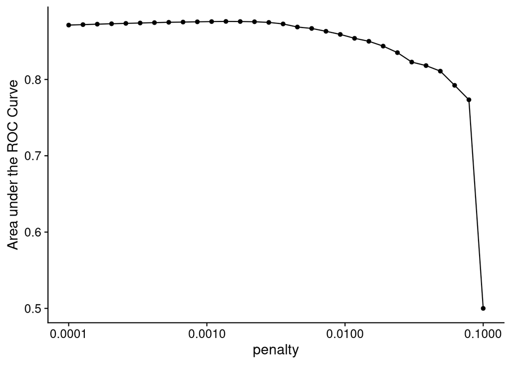

```r
lr_reg_grid_tbl <- tibble(penalty = 10^seq(-4, -1, length.out = 30))

lr_res <- lr_workflow %>%
  tune_grid(
    val_set,
    grid    = lr_reg_grid_tbl,
    control = control_grid(save_pred = TRUE),
    metrics = metric_set(roc_auc)
    )


plot_tbl <- lr_res %>%
  collect_metrics()

ggplot(plot_tbl, aes(x = penalty, y = mean)) +
  geom_point() +
  geom_line() +
  ylab("Area under the ROC Curve") +
  scale_x_log10(labels = scales::label_number())
```

```r
top_models_tbl <- lr_res %>%
  show_best("roc_auc", n = 15) %>%
  arrange(penalty)

top_models_tbl %>% print()
```

```
# A tibble: 15 × 7
    penalty .metric .estimator  mean     n std_err .config
      <dbl> <chr>   <chr>      <dbl> <int>   <dbl> <chr>
 1 0.000127 roc_auc binary     0.872     1      NA Preprocessor1_Model02
 2 0.000161 roc_auc binary     0.872     1      NA Preprocessor1_Model03
 3 0.000204 roc_auc binary     0.873     1      NA Preprocessor1_Model04
 4 0.000259 roc_auc binary     0.873     1      NA Preprocessor1_Model05
 5 0.000329 roc_auc binary     0.874     1      NA Preprocessor1_Model06
 6 0.000418 roc_auc binary     0.874     1      NA Preprocessor1_Model07
 7 0.000530 roc_auc binary     0.875     1      NA Preprocessor1_Model08
 8 0.000672 roc_auc binary     0.875     1      NA Preprocessor1_Model09
 9 0.000853 roc_auc binary     0.876     1      NA Preprocessor1_Model10
10 0.00108  roc_auc binary     0.876     1      NA Preprocessor1_Model11
11 0.00137  roc_auc binary     0.876     1      NA Preprocessor1_Model12
12 0.00174  roc_auc binary     0.876     1      NA Preprocessor1_Model13
13 0.00221  roc_auc binary     0.876     1      NA Preprocessor1_Model14
14 0.00281  roc_auc binary     0.875     1      NA Preprocessor1_Model15
15 0.00356  roc_auc binary     0.873     1      NA Preprocessor1_Model16
```

We now want to choose a ‘best’ model.

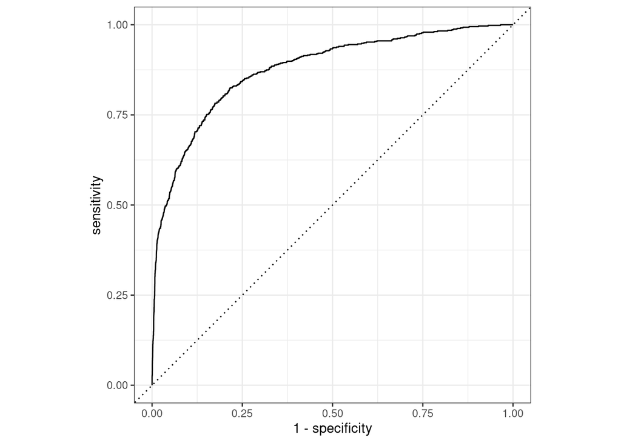

```r
lr_best_tbl <- lr_res %>%
  collect_metrics() %>%
  arrange(penalty) %>%
  slice(12)

lr_auc <- lr_res %>%
  collect_predictions(parameters = lr_best_tbl) %>%
  roc_curve(children, .pred_children) %>%
  mutate(model = "Logistic Regression")

autoplot(lr_auc)
```

## 5.4 Second Model - Random Forests with ranger

```r
rf_mod <- rand_forest(
    mtry = tune(),
    min_n = tune(),
    trees = 1000
    ) %>%
  set_engine("ranger", num.threads = getOption("mc.cores")) %>%
  set_mode("classification")


rf_recipe <- recipe(
    children ~ .,
    data = hotel_other_tbl
    ) %>%
  step_date(arrival_date) %>%
  step_holiday(arrival_date) %>%
  step_rm(arrival_date)

rf_workflow <- workflow() %>%
  add_model(rf_mod) %>%
  add_recipe(rf_recipe)
```

```r
extract_parameter_set_dials(rf_mod)
```

```
Collection of 2 parameters for tuning

 identifier  type    object
       mtry  mtry nparam[?]
      min_n min_n nparam[+]

Model parameters needing finalization:
   # Randomly Selected Predictors ('mtry')

See `?dials::finalize` or `?dials::update.parameters` for more information.
```

```r
set.seed(345)

rf_res <- rf_workflow %>%
  tune_grid(
    val_set,
    grid = 25,
    control = control_grid(save_pred = TRUE),
    metrics = metric_set(roc_auc)
    )
```

```
i Creating pre-processing data to finalize unknown parameter: mtry
```

```r
rf_res %>% show_best(metric = "roc_auc")
```

```
# A tibble: 5 × 8
   mtry min_n .metric .estimator  mean     n std_err .config
  <int> <int> <chr>   <chr>      <dbl> <int>   <dbl> <chr>
1     8     7 roc_auc binary     0.926     1      NA Preprocessor1_Model13
2    12     7 roc_auc binary     0.925     1      NA Preprocessor1_Model01
3     9    12 roc_auc binary     0.925     1      NA Preprocessor1_Model19
4     7    25 roc_auc binary     0.924     1      NA Preprocessor1_Model03
5    13     4 roc_auc binary     0.924     1      NA Preprocessor1_Model05
```

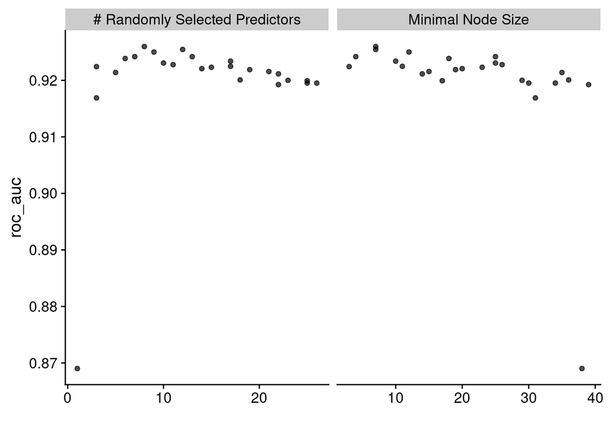

```r
autoplot(rf_res)
```

```r
rf_best <- rf_res %>% select_best(metric = "roc_auc")

rf_res %>% collect_predictions()
```

```
# A tibble: 187,500 × 8
   id         .pred_children .pred_none  .row  mtry min_n children .config
   <chr>               <dbl>      <dbl> <int> <int> <int> <fct>    <chr>
 1 validation       0.148         0.852    13    12     7 none     Preprocessor…
 2 validation       0.0262        0.974    20    12     7 none     Preprocessor…
 3 validation       0.472         0.528    22    12     7 children Preprocessor…
 4 validation       0.00918       0.991    23    12     7 none     Preprocessor…
 5 validation       0.0110        0.989    31    12     7 none     Preprocessor…
 6 validation       0.000643      0.999    38    12     7 none     Preprocessor…
 7 validation       0             1        39    12     7 none     Preprocessor…
 8 validation       0.00235       0.998    50    12     7 none     Preprocessor…
 9 validation       0.0217        0.978    54    12     7 none     Preprocessor…
10 validation       0.0389        0.961    57    12     7 children Preprocessor…
# … with 187,490 more rows
```

Finally, we show some statistics based on this ‘best’ model.

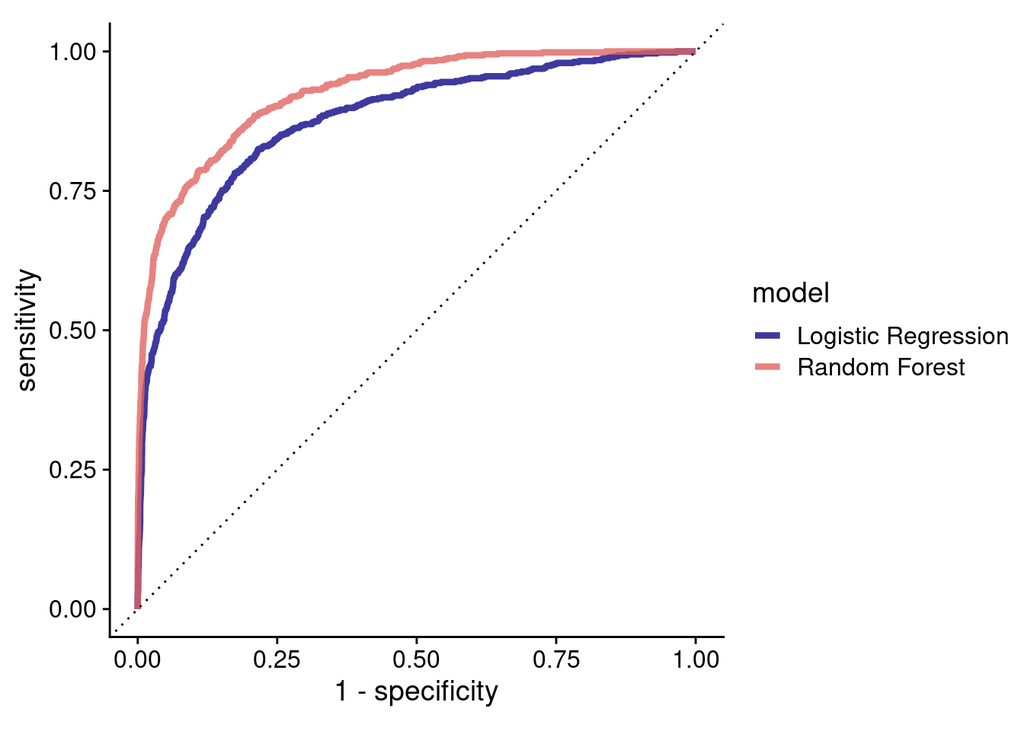

```r
rf_auc <- rf_res %>%
  collect_predictions(parameters = rf_best) %>%
  roc_curve(children, .pred_children) %>%
  mutate(
    model = "Random Forest"
    )


plot_tbl <- bind_rows(rf_auc, lr_auc)

ggplot(
    plot_tbl,
    aes(x = 1 - specificity, y = sensitivity, col = model)
    ) +
  geom_path(lwd = 1.5, alpha = 0.8) +
  geom_abline(lty = 3) +
  coord_equal() +
  scale_color_viridis_d(option = "plasma", end = .6)
```

## 5.5 Final Fit

```r
# the last model
last_rf_mod <- rand_forest(mtry = 8, min_n = 7, trees = 1000) %>%
  set_engine("ranger", num.threads = getOption("mc.cores"), importance = "impurity") %>%
  set_mode("classification")

# the last workflow
last_rf_workflow <- rf_workflow %>%
  update_model(last_rf_mod)

# the last fit
set.seed(345)

last_rf_fit <- last_rf_workflow %>% last_fit(splits)

last_rf_fit %>% print()
```

```
# Resampling results
# Manual resampling
# A tibble: 1 × 6
  splits                id               .metrics .notes   .predict…¹ .workflow
  <list>                <chr>            <list>   <list>   <list>     <list>
1 <split [37500/12500]> train/test split <tibble> <tibble> <tibble>   <workflow>
# … with abbreviated variable name ¹.predictions
```

```r
last_rf_fit %>% collect_metrics()
```

```
# A tibble: 2 × 4
  .metric  .estimator .estimate .config
  <chr>    <chr>          <dbl> <chr>
1 accuracy binary         0.946 Preprocessor1_Model1
2 roc_auc  binary         0.924 Preprocessor1_Model1
```

We now want to look for variable importance

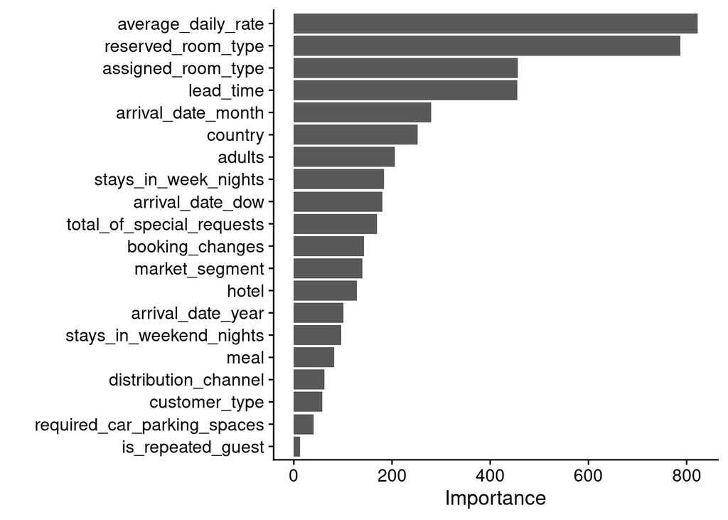

```r
last_rf_fit %>%
  extract_fit_parsnip() %>%
  vip(num_features = 20)
```

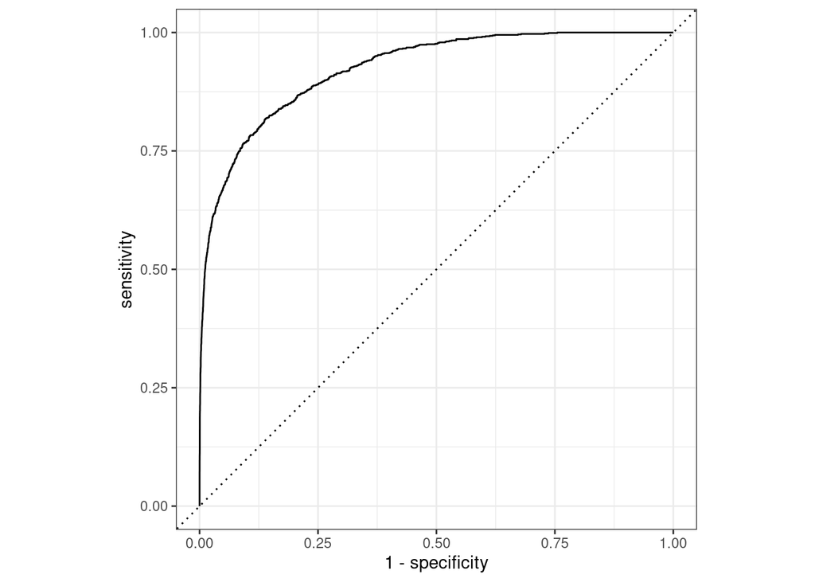

```r
last_rf_fit %>%
  collect_predictions() %>%
  roc_curve(children, .pred_children) %>%
  autoplot()
```